# Encontro dos Saberes RESEX Cazumbá-Iracema (2022)

Análise mamíferos terrestres – 2014 a 2021

Elildo Carvalho Jr - ICMBio/CENAP

2022-03-18

## Apresentação

Este relatório apresenta resultados do Programa Monitora, Subprograma Terrestre, Componente Florestal Global, Alvo Mamíferos terrestres de médio e grande porte, protocolo básico, na **Reserva Extrativista Cazumbá-Iracema**, 2014 a 2021. O principal objetivo é subsidiar o Encontro dos Saberes que será realizado nesta unidade.

Por se tratar de um relatório simplificado, este documento não inclui detalhes sobre métodos de coleta ou análise dos dados. Ele também não inclui detalhes sobre o esforço de amostragem, pois essa informação já consta do relatório produzido pelo CEMAVE. Portanto, o relatório apenas apresenta as variações anuais nas populações de espécies selecionadas de mamíferos de médio e grande porte.

## Número total de encontros

A tabela 1 apresenta o número total de encontros e de indivíduos avistados por espécie.

As espécies mais encontradas foram, nessa ordem: quatipuru, cutia, caititu, cutiara e veado mateiro. Os quatipurus incluem três espécies diferentes, que foram agrupadas. As outras espécies foram encontradas poucas vezes.

Algumas espécies vivem em grupos, por isso o número indivíduos pode ser maior do que o número de encontros. Por exemplo, o caititu, que vive em grupos, ficou em terceiro lugar no número de encontros, mas em primeiro lugar no número de indivíduos.

É importante lembrar que só porque uma espécie foi registrada poucas vezes, não quer dizer necessariamente que ela seja rara. Por exemplo, o protocolo não funciona bem para espécies noturnas como as antas e as pacas, pois as trilhas são percorridas durante o dia, quando essas espécies estão menos ativas. Além disso, espécies que são caçadas podem ficar muito ariscas, fugindo ao menor sinal da aproximação de pessoas.

Numero de registros por especie obtidos pelo protocolo básico do Programa Monitora na Resex Cazumbá-Iracema, 2014-2021

| Ordem | Familia | Especie | Nome popular | Encontros | Individuos |
| --- | --- | --- | --- | --- | --- |
| Artiodactyla | Cervidae | Mazama americana | Veado-mateiro | 31 | 32 |
| Artiodactyla | Tayassuidae | Pecari tajacu | Caititu | 98 | 347 |
| Artiodactyla | Tayassuidae | Tayassu pecari | Queixada | 2 | 16 |
| Carnivora | Canidae | Speothos venaticus | Janauira | 1 | 1 |
| Carnivora | Felidae | Leopardus pardalis | Maracajá-açu | 1 | 1 |
| Carnivora | Felidae | Leopardus tigrinus | Gato-do-mato | 4 | 4 |
| Carnivora | Felidae | Leopardus wiedii | Maracajá-peludo | 3 | 4 |
| Carnivora | Felidae | Panthera onca | Onça-pintada | 3 | 3 |
| Carnivora | Felidae | Puma concolor | Onça-vermelha | 1 | 1 |
| Carnivora | Felidae | Puma yagouaroundi | Gato-mourisco | 1 | 1 |
| Carnivora | Mustelidae | Eira barbara | Irara | 18 | 26 |
| Carnivora | Mustelidae | Galictis vittata | Furão | 1 | 2 |
| Carnivora | Procyonidae | Nasua nasua | Quati | 26 | 168 |
| Cingulata | Dasypodidae | Cabassous unicinctus | Tatu-de-rabo-mole | 4 | 4 |
| Cingulata | Dasypodidae | Dasypus novemcinctus | no | 2 | 2 |
| Cingulata | Dasypodidae | Priodontes maximus | Tatu-canastra | 2 | 6 |
| Perissodactyla | Tapiridae | Tapirus terrestris | Anta | 1 | 1 |
| Pilosa | Bradypodidae | Bradypus variegatus | Preguiça | 2 | 2 |
| Pilosa | Bradypodidae | Choloepus hoffmanni | Preguiça-real | 1 | 1 |
| Pilosa | Myrmecophagidae | Myrmecophaga tridactyla | Tamanduá-bandeira | 8 | 8 |
| Pilosa | Myrmecophagidae | Tamandua tetradactyla | Mambira | 14 | 14 |
| Rodentia | Dasyproctidae | Dasyprocta fuliginosa | Cutia | 158 | 181 |
| Rodentia | Dasyproctidae | Myoprocta pratti | Cutiara | 74 | 77 |
| Rodentia | Erethizontidae | Coendou bicolor | Quandú | 1 | 1 |
| Rodentia | Sciuridae | Sciuridae | Quatipuru | 230 | 286 |

## Tendências populacionais

Nesta seção, incluímos somente as quatro espécies que apresentaram taxa de encontro anual média > 0.05 ind/km: quatipuru, cutia, caititu e cutiara (Tabela 2, Figuras 1 a 4). As outras especies não tiveram número de eoncontros suficiente para permitir uma análise de suas tendências populacionais.

| especie | 2014 | 2015 | 2016 | 2017 | 2018 | 2019 | 2020 | 2021 | means |
| --- | --- | --- | --- | --- | --- | --- | --- | --- | --- |
| Sciuridae | 0.25 | 0.19 | 0.28 | 0.20 | 0.25 | 0.25 | 0.05 | 0.06 | 0.1916667 |
| Dasyprocta fuliginosa | 0.15 | 0.15 | 0.15 | 0.06 | 0.11 | 0.14 | 0.15 | 0.14 | 0.1316667 |
| Pecari tajacu | 0.11 | 0.09 | 0.07 | 0.07 | 0.12 | 0.07 | 0.07 | 0.07 | 0.0816667 |
| Myoprocta pratti | 0.05 | 0.08 | 0.09 | 0.04 | 0.05 | 0.04 | 0.11 | 0.04 | 0.0616667 |

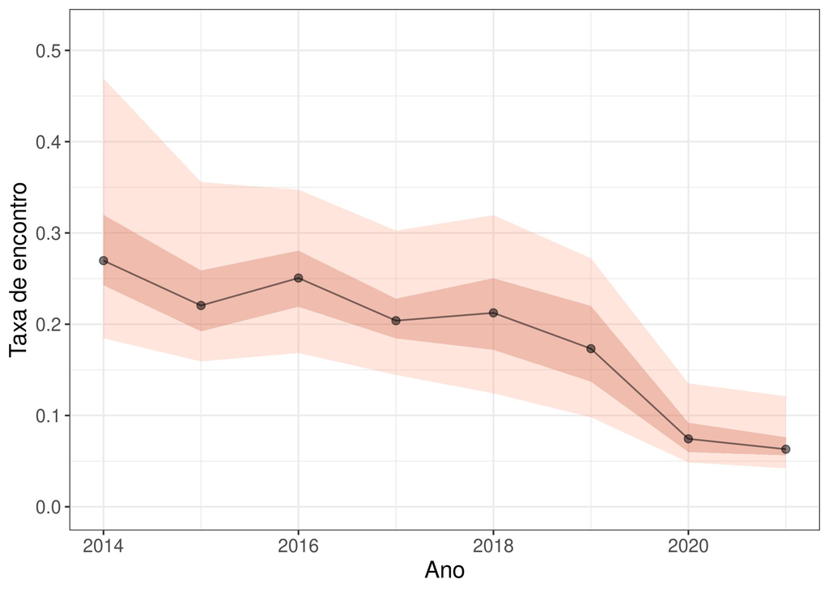

Taxa de encontro anual para Quatipuru na Resex Cazumbá-Iracema, 2014-2021

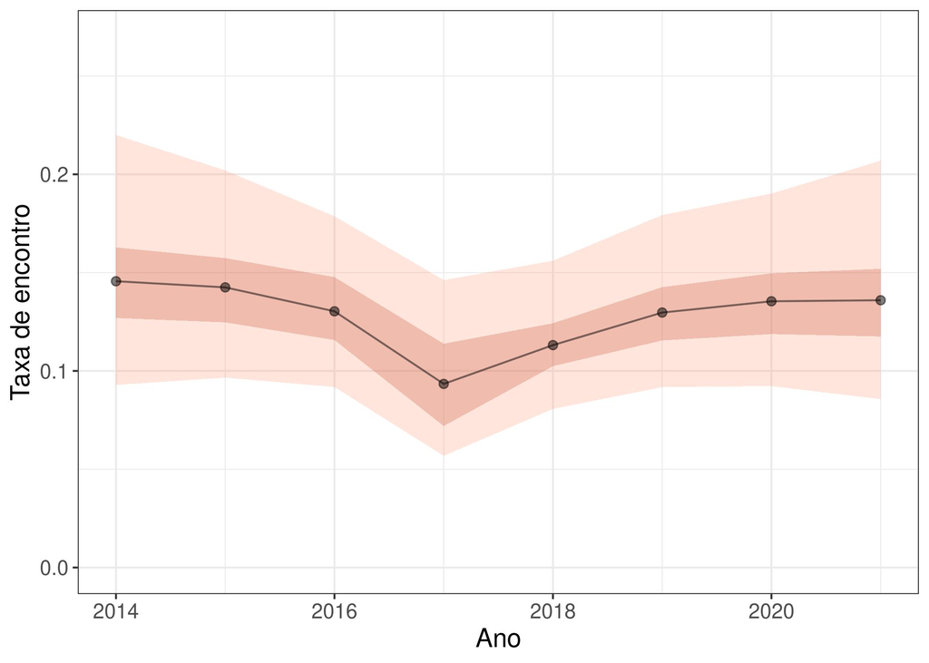

Taxa de encontro anual para Cutia (*Dasyprocta fuliginosa*) na Resex Cazumbá-Iracema, 2014-2021

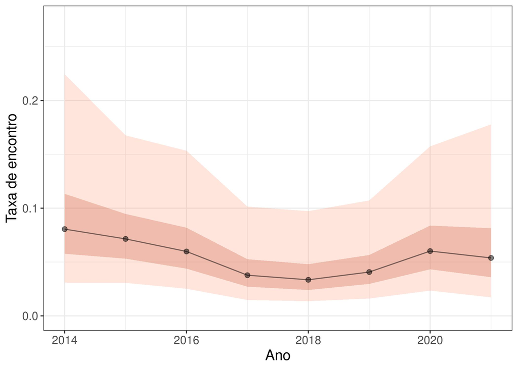

Taxa de encontro anual para Cutiara (*Myoprocta pratti*) na Resex Cazumbá-Iracema, 2014-2021

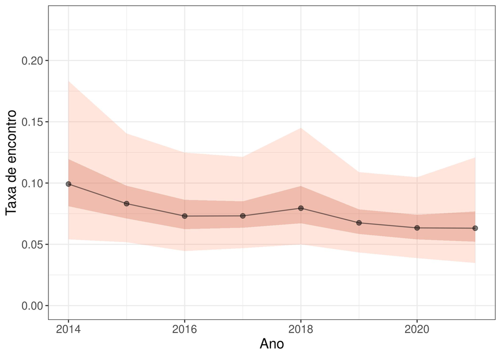

Taxa de encontro anual para Caititu (*Pecari tajacu*) na Resex Cazumbá-Iracema, 2014-2021